# Coursework Report

*N* removed NAs: 3

*N* removed typo: 1

*N* removed <18: 17

*N* total clean: 129

| Group | *N* | *M*<sub>age</sub> | *M*<sub>rating</sub> |
| --- | --- | --- | --- |
| Control | 65 | 20.78 | 6.58 |
| Experim | 64 | 20.88 | 6.01 |

**Main analysis results**

*t*(127) = 4.13, *p* < .001

[interactive chart not shown]

[figure not shown]

[interactive chart not shown]

# Coursework Report

Analysing Data, Spring 2020

# Methods

## Participants

Table 1 *Descriptive statistics by Condition*

| Condition | *N* | % | *M*<sub>age</sub> | *SD*<sub>age</sub> |
| --- | --- | --- | --- | --- |
| White | 65 | 50.39 | 20.78 | 2.10 |
| Red | 64 | 49.61 | 20.88 | 2.09 |

## Design

Examined in this study was the hypothesis that red enhances women’s attraction to men. This was explored by looking at the effect of the colours red and white on women’s perceptions of a man’s attractiveness in an attempt to replicate Elliot et al’s (2010) findings. The independent variable, colour, was categorical and had two levels where participants saw a black and white photo of a man with either a red background (experimental condition) or with a white background (control condition). The dependent variable was a rating of perceived attractiveness, assessed using three face-valid items: “How attractive do you think this person is?”, “How pleasant is this person to look at?” and “If I were to meet the person in this picture face to face, I would think he is attractive”. The items were rated on a nine-point scale which ranged from one (not attractive) to nine (extremely attractive). Consistent with evidence of existing literature, we hypothesised that the participant’s mean ratings of attractiveness will significantly differ between the colour conditions. That is, a p-value below our significance level which is .05. To analyse the influence of colour on perceived attractiveness, an independent-measures *t*-test will be used.

# Results

We investigated whether, as predicted, women’s perceptions of a man’s attractiveness would differ between the colour conditions. As can be seen in Table 2, the composite score is greater for the white condition (control) than for the red condition (experimental) illustrating that the female subjects perceived the man presented in front a white background as more attractive.

Table 2 *Composite score by Condition*

| Condition | *N* | Composite Score |
| --- | --- | --- |
| White | 65 | 6.58 |
| Red | 64 | 6.01 |

To analyse the data, an independent-measures *t*-test was used which revealed that the mean ratings of attractiveness differed between the colour conditions (*M*<sub>diff</sub> = 0.57, 95% CI [0.3, 0.84]) and that the difference between the two groups is statistically significant *t* (127) = 4.13, *p* < .001. As the p-value is below our predetermined significance level .05, it can be considered statistically significant which means that our results aren’t likely due to chance and that it’s improbable to find a test statistic as large as the one we found, if the null hypothesis is true. Futhermore, the participants in the white condition compared with those in the red condition rated the man as more attractive (*M* = 6.58 and *M* = 6.01, respectively), indicating that the colour white is more influential on women’s perceptions of attractiveness. Thus, the results disprove the theory of the red effect on attractiveness. A figure of the data can be seen below.

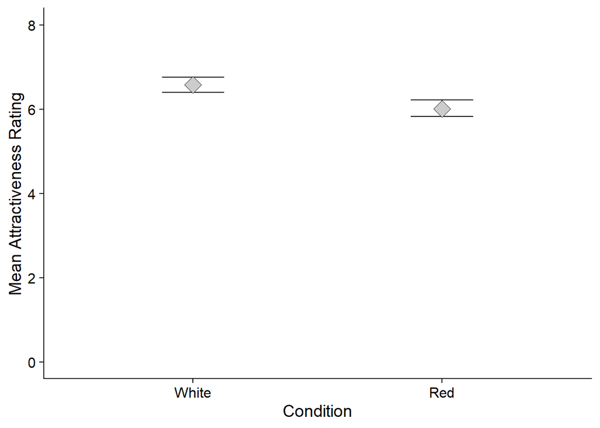

# Discussion

Women’s attraction to men is of great interest to the scientific community. A wealth of existing research into women’s preferences indicates that not only do physical features such as a symmetrical face and a muscular body increase attraction to men (Dixson et al, 2003; Rhodes et al, 1998) but non-physical features such as the colour red also have an influence (Elliot et al, 2010). As such, the present research was conducted to test the hypothesis that red enhances women’s attraction to men, replicating the basic paradigm used by Elliot et al (2010).

Contrary to our expectations, we found that women’s perceived attractiveness ratings increased when a male was seen in conjunction with the colour white. Higher attractiveness ratings weren’t found in the red condition, instead a white effect on attractiveness emerged. The results indicate that an effect was observed as the difference between the groups is of high statistical significance, though, they are inconsistent with those of the original study. In comparison to the present research, Elliot et al revealed a significant colour effect, with the participants in the red condition relative to those in the white condition, rating the target man as more attractive. The findings lend support for the red effect, documenting the colour as a novel determinant of women’s preferences and desires. However, the lack of evidence for the red effect from our study leads us to question the robustness of the colour in female mate preferences

While the original study may seem strikingly convincing, since the authors were repeatedly able to replicate their results, further replications have too found refuting evidence for the hypothesis that red enhances women’s attraction to men. Despite having tested a larger sample of participants, neither of Hesslinger et al’s (2015) replications yielded a significant effect of the colour red on perceived attractiveness which implies the relationship isn’t as strong as Elliot et al’s research might initially suggest. This is consistent with Elliot & Maier (2013) who found that women in the red condition gave the target man higher ratings of attraction, but the difference between the conditions fell short of statistical significance. Although the results followed a similar direction to the original study, they weren’t as robust which left them inconclusive regarding the red effect.

Notwithstanding the successful replications reported by Elliot et al, an analysis of the statistics revealed the experiment lacks sufficient power to support the claim that the colour red modifies women’s ratings of attractiveness (Francis, 2010). The interpretation of the reported results is that the study is contaminated with publication bias, due to either null findings having not been reported or the experiment being run indecorously which increased the likelihood of rejecting the null hypothesis (Francis). Thus, the results can be considered non-scientific. In addition to this, the subjects in Elliot et al’s study were only presented with one photograph of a moderately attractive man, restricting the generalisability of the findings. The stimulus material is far from reflective of the variability in physical appearances, hence it remains inconclusive as to whether the effect of red applies solely to those of an average attractiveness level. As the present research was limited to the paradigm used by Elliot et al, this also becomes problematic for our findings and weakens the external validity.

Common within literature examining the red effect, including this replication, is the use of samples with a limited age range; the average participant age is 20 years and so the conclusions that have been drawn are based on younger women’s perspectives. This provides scope for new and interesting research to be carried out, assessing whether red enhances women’s attraction to men at more mature stages of their life. Throughout the animal kingdom, numerous species exhibit a link between status and red ornamentation. Red is an indicator of high status in male animals such as mandrills (Setchell & Dixson, 2001), lizards (Healey et al, 2007) and sticklebacks (Bakker & Sevenster, 1983) displayed most often during the mating season and following competition for territory. As high-status males possess the ability to provide physical protection, food and genetic advantages to their offspring, female’s view them as the optimal mating partner (Buss, 1989). Perhaps red may be a positive indicator for women around the age 30, since this is a prime period for reproduction (OECD, 2019) and a time in which they will need access to social and economic resources. It’s therefore reasonable to posit that women’s perceptions of attractiveness, during middle adulthood, could be influenced by the colour red.

Within the present research and other sources of literature examining the red effect, both very small sample sizes and limited cultural perspectives were tested; consequently, the findings are only generalizable to a certain extent. To gain a thorough understanding of whether red enhances women’s perceived attractiveness, research needs to be carried out on a wider scale using a greater variety of cultures. Across many cultures, red carries an amorous meaning as a symbol of romantic love, passion and lust (Aslam, 2006; Jacobs et al, 1991) and played a fundamental role in expressing wealth, authority and status in ancient times (Donkin, 1997; Gage, 1999). In Western countries, red is a symbol of love and excitement, in India red evokes purity, in Latin American countries red has religious connotations, in the Middle East red is a sign of danger and in China it symbolizes luck and happiness (Eriksen, 2020). Therefore, by assessing the influence of the colour red on attractiveness across different cultures, we would be able to identify if and where it’s applicable, possibly revealing whether the colour has had an evolutionary advantage.

The purpose of the present study was to replicate and extend research supporting the claim that red enhances women’s attraction to men. To our surprise, however, a white effect on attractiveness emerged. Our findings revealed that women’s perceived attractiveness ratings increased when a male was seen in conjunction with the colour white, inconsistent with those of the original study but consistent with other replications. Since there is a lack of consensus on the red effect, further study is needed to consolidate this research question; assessing different age categories and incorporating a variety of cultures would help to produce the best outcome. As such, it remains an open question whether the colour red influences women’s perceptions of a man’s attractiveness.

# References

Aslam, M. M. (2006). Are you selling the right colour? A cross-cultural review of colour as a marketing cue. *Journal of Marketing Communications, 12,* pp. 15–30.

Bakker, T. C. M., & Sevenster, P. (1983). Determinants of dominance in male sticklebacks (Gasterosteus aculeatus L.). *Behaviour, 86,* pp. 55–71.

Buss, D. M. (1989). Sex differences in human mate preference: Evolutionary hypothesis tested in 37 cultures. *Behavioral and Brain Sciences, 12,* pp. 1– 49.

Dixson, A.F., Halliwell, G., East, R., Wignarajah, P., & Anderson, M. J. (2003). Masculine somatotype and hirsuteness as determinants of sexual attractiveness to women. *Arch. Sex. Behav, 32,* pp. 29–39.

Donkin, R. A. (1977). Spanish red: An ethnogeographical study of cochineal and the opuntia cactus. *Transactions of the American Philosophical Society, 67,* pp. 5–78.

Elliot, A. J., & Maier, M. A. (2013). The red-attractiveness effect, applying the Ioannidis and Trikalinos (2007b) test, and the broader scientific context: A reply to Francis (2013). *Journal of Experimental Psychology: General, 142*(1), pp. 297–300. doi:10.1037/a0029592

Elliot, A. J., Kayser, D. N., Greitemeyer, T., Lichtenfeld, S., Gramzow, R. H., Maier, M. A., & Liu, H. (2010). Red rank and romance in women viewing men. *Journal of Experimental Psychology: General, 139*(3), pp. 399–417.

Eriksen Translations. (2020). How translating colours across cultures can help you make a positive impact. Retrieved from: https://www.eriksen.com/marketing/color_culture/.

Francis, G. (2013). Publication bias in “Red, rank, and romance in women viewing men,” by Elliot et al. (2010). *Journal of Experimental Psychology: General, 142*(1), pp. 292–296. doi:10.1037/a0027923

Gage, J. (1999). *Colour and meaning: Art, science and symbolism*. London, England: Thames & Hudson.

Healey, M., Uller, T., & Olsson, M. (2007). Seeing red: Morph-specific contest success, and survival rates, in a colour-polymorphic agamid lizard. *Animal Behaviour, 73,* pp. 337–341.

Hesslinger, V.M., Goldbach, L. & Carbon, C. (2015). Men in red: A re-examination of the red-attractiveness effect. *Psychon Bull Rev 22,* pp. 1142–1148. Doi: https://doi.org/10.3758/s13423-015-0866-8

Jacobs, L., Keown, C., Worthley, R., & Gyhmn, K. (1991). Cross-cultural color comparisons: Global marketers beware! *International Marketing Review, 8,* pp. 21–30.

OECD. (2019). OECD Family Database. Retrieved from: http://www.oecd.org/els/family/database.htm.

(1998). Facial symmetry and the perception of beauty. *Psychonom. Bull. Rev, 5,* pp. 659–69.

Setchell, J. M., & Dixson, A. F. (2001). Changes in the secondary sexual adornments of male mandrills (Mandrillus sphinx) are associated with gain and loss of alpha status. *Hormones and Behavior, 39,* pp. 177–184.